# SUDHARSHANA.S_PGPDSBA_Oct_C'21_9 April 2022

```python
intercept = regression_model.intercept_[0]

print("The intercept for our model is {}".format(intercept))
```

```
The intercept for our model is 7895.921294608928
```

```python
# R square on training data
regression_model.score(X_train, y_train)
```

```
0.9194449968572139
```

```python
# R square on testing data
regression_model.score(X_test, y_test)
```

```
0.9232827894622646
```

```python
#RMSE on Training data
from sklearn import metrics
predicted_train=regression_model.fit(X_train, y_train).predict(X_train)
np.sqrt(metrics.mean_squared_error(y_train,predicted_train))
```

```
1137.5777778316658
```

```python
#RMSE on Testing data
predicted_test=regression_model.fit(X_train, y_train).predict(X_test)

np.sqrt(metrics.mean_squared_error(y_test,predicted_test))
```

```
1121.9471160369574
```

```python
import statsmodels.api as sm
X_train = sm.add_constant(X_train) # adding a constant

model = sm.OLS(y_train, X_train).fit()
predictions = model.predict(X_train)

print_model = model.summary()
print(print_model)
```

```
                            OLS Regression Results
==============================================================================
Dep. Variable:                  price   R-squared:                       0.919
Model:                            OLS   Adj. R-squared:                  0.919
Method:                 Least Squares   F-statistic:                 1.074e+04
Date:                Thu, 07 Apr 2022   Prob (F-statistic):               0.00
Time:                        20:23:01   Log-Likelihood:            -1.5936e+05
No. Observations:               18847   AIC:                         3.188e+05
Df Residuals:                   18826   BIC:                         3.189e+05
Df Model:                          20
Covariance Type:            nonrobust
=================================================================================
                    coef    std err          t      P>|t|      [0.025      0.975]
---------------------------------------------------------------------------------
const          5063.0335    425.138     11.909      0.000    4229.724    5896.343
carat          1.159e+04     88.261    131.321      0.000    1.14e+04    1.18e+04
depth           -83.1995      7.409    -11.229      0.000     -97.722     -68.677
table           -36.9781      4.914     -7.526      0.000     -46.609     -27.347
x             -1135.7078     47.901    -23.710      0.000   -1229.597   -1041.818
y                -5.9365     22.390     -0.265      0.791     -49.823      37.950
z               -39.8380     39.071     -1.020      0.308    -116.421      36.745
cut_Fair        834.0738    126.551      6.591      0.000     586.022    1082.126
cut_Ideal      1488.3391     98.191     15.158      0.000    1295.875    1680.803
cut_Premium    1399.0631    104.776     13.353      0.000    1193.692    1604.434
cut_Very Good  1341.5576    106.512     12.595      0.000    1132.785    1550.330
color_E        1663.8865     72.306     23.012      0.000    1522.160    1805.613
color_F        1525.4140     73.425     20.775      0.000    1381.494    1669.334
color_G        1331.1070     73.336     18.151      0.000    1187.362    1474.852
color_H         812.6655     73.591     11.043      0.000     668.421     956.910
color_I         265.2462     74.777      3.547      0.000     118.676     411.816
color_J        -535.2858     77.468     -6.910      0.000    -687.130    -383.441
clarity_I1    -2908.0828     90.414    -32.164      0.000   -3085.302   -2730.863
clarity_IF     2285.6235     70.975     32.203      0.000    2146.506    2424.741
clarity_SI1     658.9002     65.388     10.077      0.000     530.733     787.067
clarity_SI2    -317.0558     65.964     -4.807      0.000    -446.351    -187.761
clarity_VS2    1392.8752     63.384     21.975      0.000    1268.637    1517.113
clarity_VVS1   1988.3570     66.716     29.803      0.000    1857.587    2119.127
clarity_VVS2   1962.4163     65.572     29.928      0.000    1833.889    2090.943
==============================================================================
Omnibus:                     5099.367   Durbin-Watson:                   1.990
Prob(Omnibus):                  0.000   Jarque-Bera (JB):           189394.319
Skew:                           0.608   Prob(JB):                         0.00
Kurtosis:                      18.482   Cond. No.                     1.26e+18
==============================================================================

Notes:
[1] Standard Errors assume that the covariance matrix of the errors is correctly specified.
[2] The smallest eigenvalue is 8.53e-29. This might indicate that there are
strong multicollinearity problems or that the design matrix is singular.
```

```python
import statsmodels.api as sm
X_train = sm.add_constant(X_test) # adding a constant

model = sm.OLS(y_test, X_test).fit()
predictions = model.predict(X_test)

print_model = model.summary()
print(print_model)
```

```
                            OLS Regression Results
==============================================================================
Dep. Variable:                  price   R-squared:                       0.925
Model:                            OLS   Adj. R-squared:                  0.925
Method:                 Least Squares   F-statistic:                     4953.
Date:                Thu, 07 Apr 2022   Prob (F-statistic):               0.00
Time:                        20:04:04   Log-Likelihood:                -68113.
No. Observations:                8078   AIC:                         1.363e+05
Df Residuals:                    8057   BIC:                         1.364e+05
Df Model:                          20
Covariance Type:            nonrobust
=================================================================================
                    coef    std err          t      P>|t|      [0.025      0.975]
---------------------------------------------------------------------------------
carat          1.177e+04    130.262     90.376      0.000    1.15e+04     1.2e+04
depth            90.8543     23.986      3.788      0.000      43.835     137.873
table           -16.0968      7.392     -2.178      0.029     -30.587      -1.607
x             -1375.1606    201.237     -6.834      0.000   -1769.637    -980.684
y              1823.8902    213.162      8.556      0.000    1406.038    2241.742
z             -2734.6605    362.436     -7.545      0.000   -3445.129   -2024.192
cut_Fair      -2404.4359    736.060     -3.267      0.001   -3847.304    -961.567
cut_Ideal     -1453.4988    717.581     -2.026      0.043   -2860.143     -46.855
cut_Premium   -1518.4837    721.845     -2.104      0.035   -2933.487    -103.480
cut_Very Good -1636.2656    725.344     -2.256      0.024   -3058.128    -214.403
color_E        -344.9441    482.992     -0.714      0.475   -1291.733     601.844
color_F        -489.0871    482.858     -1.013      0.311   -1435.614     457.440
color_G        -652.7390    483.365     -1.350      0.177   -1600.259     294.781
color_H       -1182.6040    483.515     -2.446      0.014   -2130.418    -234.790
color_I       -1641.2841    484.863     -3.385      0.001   -2591.741    -690.827
color_J       -2702.0256    485.914     -5.561      0.000   -3654.542   -1749.509
clarity_I1    -4980.2772    425.108    -11.715      0.000   -5813.599   -4146.956
clarity_IF      541.2688    417.358      1.297      0.195    -276.860    1359.397
clarity_SI1    -951.8485    416.818     -2.284      0.022   -1768.920    -134.777
clarity_SI2   -1918.2762    416.494     -4.606      0.000   -2734.712   -1101.840
clarity_VS2    -263.2968    415.375     -0.634      0.526   -1077.539     550.946
clarity_VVS1    325.5847    414.161      0.786      0.432    -486.279    1137.448
clarity_VVS2    234.1614    415.294      0.564      0.573    -579.922    1048.245
==============================================================================
Omnibus:                     2025.211   Durbin-Watson:                   2.006
Prob(Omnibus):                  0.000   Jarque-Bera (JB):            53610.946
Skew:                           0.608   Prob(JB):                         0.00
Kurtosis:                      15.562   Cond. No.                     9.60e+17
==============================================================================

Notes:
[1] Standard Errors assume that the covariance matrix of the errors is correctly specified.
[2] The smallest eigenvalue is 6.31e-29. This might indicate that there are
strong multicollinearity problems or that the design matrix is singular.
```

```python
# concatenate X and y into a single dataframe
data_train = pd.concat([X_train, y_train], axis=1)
data_test=pd.concat([X_test,y_test],axis=1)
```

```python
# Calculate MSE
mse = np.mean((model.predict(data_train.drop('price',axis=1))-data_train['price'])**2)
```

```python
#Root Mean Squared Error - RMSE
np.sqrt(mse)
```

[output not shown]

```python
# Prediction on Test data
y_pred = model.predict(data_test)
```

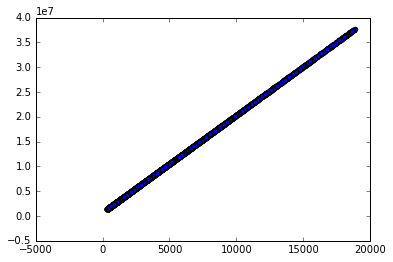

```python
plt.scatter(y_test['price'], y_pred)
plt.show()
```

```python
for i,j in np.array(model.params.reset_index()):
    print('({}) * {} +'.format(round(j,2),i),end=' ')
```

[output not shown]

2.1 Data Ingestion: Read the dataset. Do the descriptive statistics and do null value condition check, write an inference on it. Perform Univariate and Bivariate Analysis. Do exploratory data analysis.

```python
import numpy as np
import pandas as pd
import matplotlib.pyplot as plt
import seaborn as sns
from sklearn.model_selection import train_test_split,GridSearchCV
from sklearn.linear_model import LogisticRegression
from sklearn import metrics
from sklearn.metrics import roc_auc_score,roc_curve,classification_report,confusion_matrix,plot_confusion_matrix
```

```python
data=pd.read_csv("Holiday_Package.csv")
```

```python
data.head()
```

|  | Unnamed: 0 | Holliday_Package | Salary | age | educ | no_young_children | no_older_children | foreign |
| --- | --- | --- | --- | --- | --- | --- | --- | --- |
| 0 | 1 | no | 48412 | 30 | 8 | 1 | 1 | no |
| 1 | 2 | yes | 37207 | 45 | 8 | 0 | 1 | no |
| 2 | 3 | no | 58022 | 46 | 9 | 0 | 0 | no |
| 3 | 4 | no | 66503 | 31 | 11 | 2 | 0 | no |
| 4 | 5 | no | 66734 | 44 | 12 | 0 | 2 | no |

```python
data.tail()
```

|  | Unnamed: 0 | Holliday_Package | Salary | age | educ | no_young_children | no_older_children | foreign |
| --- | --- | --- | --- | --- | --- | --- | --- | --- |
| 867 | 868 | no | 40030 | 24 | 4 | 2 | 1 | yes |
| 868 | 869 | yes | 32137 | 48 | 8 | 0 | 0 | yes |
| 869 | 870 | no | 25178 | 24 | 6 | 2 | 0 | yes |
| 870 | 871 | yes | 55958 | 41 | 10 | 0 | 1 | yes |
| 871 | 872 | no | 74659 | 51 | 10 | 0 | 0 | yes |

```python
data.info()
```

```
<class 'pandas.core.frame.DataFrame'>
RangeIndex: 872 entries, 0 to 871
Data columns (total 8 columns):
 #   Column             Non-Null Count  Dtype
---  ------             --------------  -----
 0   Unnamed: 0         872 non-null    int64
 1   Holliday_Package   872 non-null    object
 2   Salary             872 non-null    int64
 3   age                872 non-null    int64
 4   educ               872 non-null    int64
 5   no_young_children  872 non-null    int64
 6   no_older_children  872 non-null    int64
 7   foreign            872 non-null    object
dtypes: int64(6), object(2)
memory usage: 54.6+ KB
```

```python
data.describe().T
```

|  | count | mean | std | min | 25% | 50% | 75% | max |
| --- | --- | --- | --- | --- | --- | --- | --- | --- |
| Unnamed: 0 | 872.0 | 436.500000 | 251.869014 | 1.0 | 218.75 | 436.5 | 654.25 | 872.0 |
| Salary | 872.0 | 47729.172018 | 23418.668531 | 1322.0 | 35324.00 | 41903.5 | 53469.50 | 236961.0 |
| age | 872.0 | 39.955275 | 10.551675 | 20.0 | 32.00 | 39.0 | 48.00 | 62.0 |
| educ | 872.0 | 9.307339 | 3.036259 | 1.0 | 8.00 | 9.0 | 12.00 | 21.0 |
| no_young_children | 872.0 | 0.311927 | 0.612870 | 0.0 | 0.00 | 0.0 | 0.00 | 3.0 |
| no_older_children | 872.0 | 0.982798 | 1.086786 | 0.0 | 0.00 | 1.0 | 2.00 | 6.0 |

```python
data=data.drop("Unnamed: 0",axis=1)
```

```python
data.duplicated().sum()
```

```
0
```

```python
data.isnull().sum()
```

```
Holliday_Package     0
Salary               0
age                  0
educ                 0
no_young_children    0
no_older_children    0
foreign              0
dtype: int64
```

```python
for feature in data.columns:
    if data[feature].dtype == 'object':
        print(feature)
        print(data[feature].value_counts())
        print('\n')
```

```
Holliday_Package
no     471
yes    401
Name: Holliday_Package, dtype: int64


foreign
no     656
yes    216
Name: foreign, dtype: int64
```

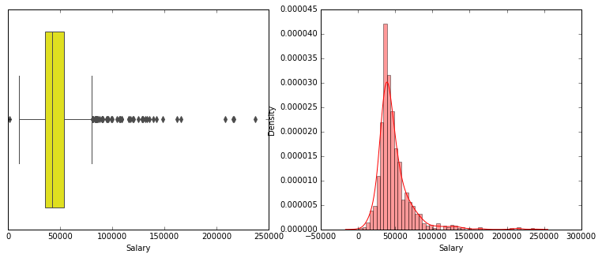

```python
fig, (ax1,ax2)=plt.subplots(1,2,figsize=(13,5))
sns.boxplot(data['Salary'],orient='horizontal',color='yellow',ax=ax1)
sns.distplot(data['Salary'],ax=ax2,color="red")
```

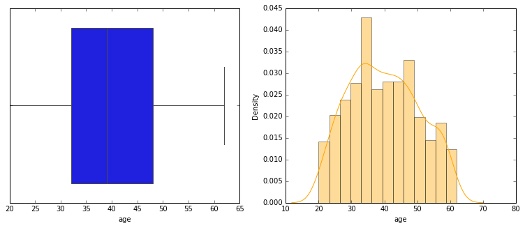

```python
fig, (ax1,ax2)=plt.subplots(1,2,figsize=(13,5))
sns.boxplot(data['age'],orient='horizontal',color='blue',ax=ax1)
sns.distplot(data['age'],ax=ax2,color="orange")
```

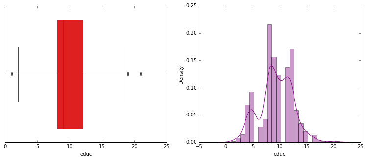

```python
fig, (ax1,ax2)=plt.subplots(1,2,figsize=(13,5))
sns.boxplot(data['educ'],orient='horizontal',color='red',ax=ax1)
sns.distplot(data['educ'],ax=ax2,color="purple")
```

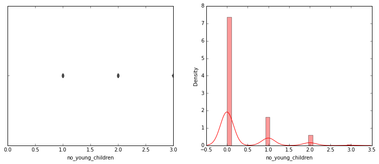

```python
fig, (ax1,ax2)=plt.subplots(1,2,figsize=(13,5))
sns.boxplot(data['no_young_children'],orient='horizontal',color='blue',ax=ax1)
sns.distplot(data['no_young_children'],ax=ax2,color="red")
```

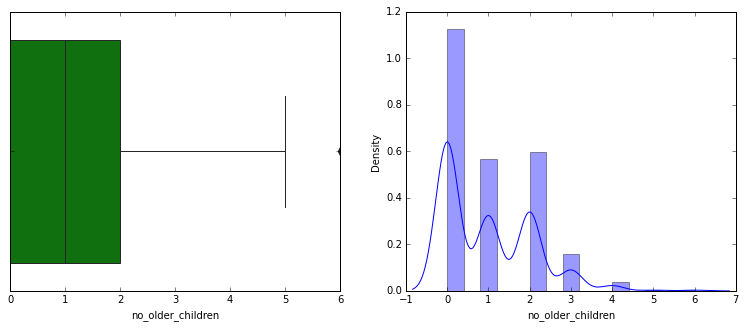

```python
fig, (ax1,ax2)=plt.subplots(1,2,figsize=(13,5))
sns.boxplot(data['no_older_children'],orient='horizontal',color='green',ax=ax1)
sns.distplot(data['no_older_children'],ax=ax2,color="blue")
```

```python
data.skew()
```

```
Salary               3.103216
age                  0.146412
educ                -0.045501
no_young_children    1.946515
no_older_children    0.953951
dtype: float64
```

```python
def check_outliers(data):
    vData_num = data.loc[:,data.columns != 'class']
    Q1 = vData_num.quantile(0.25)
    Q3 = vData_num.quantile(0.75)
    IQR = Q3 - Q1
    count = 0
    # checking for outliers, True represents outlier
    vData_num_mod = ((vData_num < (Q1 - 1.5 * IQR)) |(vData_num > (Q3 + 1.5 * IQR)))
    #iterating over columns to check for no.of outliers in each of the numerical attributes.
    for col in vData_num_mod:
        if(1 in vData_num_mod[col].value_counts().index):
            print("No. of outliers in %s: %d" %( col, vData_num_mod[col].value_counts().iloc[1]))
            count += 1
    print("\n\nNo of attributes with outliers are :", count)

check_outliers(data)
```

[output not shown]

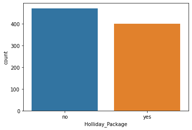

```python
sns.countplot(data["Holliday_Package"])
```

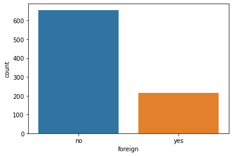

```python
sns.countplot(data["foreign"])
```

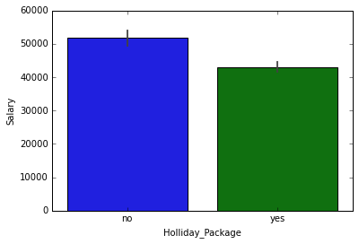

```python
sns.barplot(data = data, x='Holliday_Package',y='Salary')
```

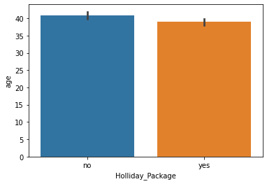

```python
sns.barplot(data = data, x='Holliday_Package',y='age')
```

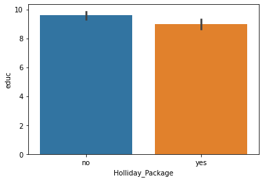

```python
sns.barplot(data = data, x='Holliday_Package',y='educ')
```

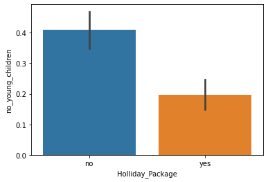

```python
sns.barplot(data = data, x='Holliday_Package',y='no_young_children')
```

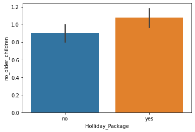

```python
sns.barplot(data = data, x='Holliday_Package',y='no_older_children')
```

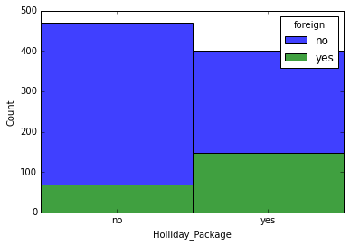

```python
sns.histplot(binwidth=0.2, x="Holliday_Package", hue="foreign", data=data, stat="count", multiple="stack")
```

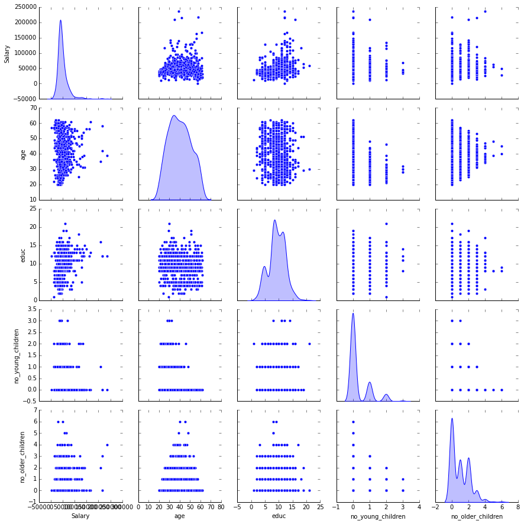

```python
sns.pairplot(data,diag_kind='kde');
```

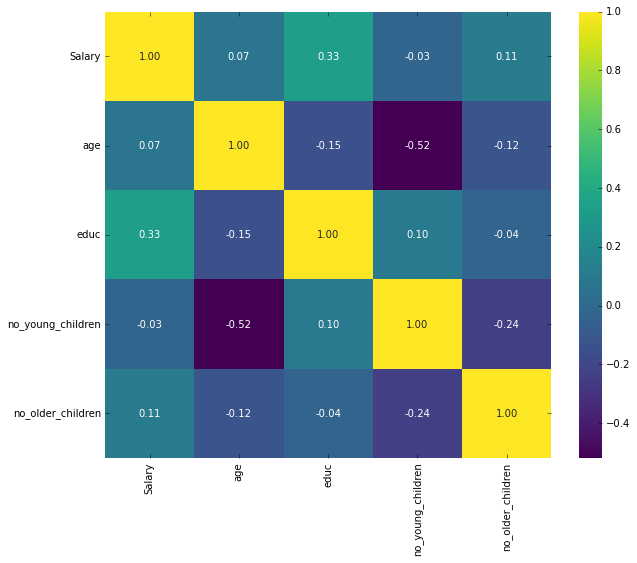

```python
plt.figure(figsize=(10,8))
sns.heatmap(data.corr(),annot=True,fmt=".2f",cmap="viridis")
plt.show()
```

2.2 Do not scale the data. Encode the data (having string values) for Modelling. Data Split: Split the data into train and test (70:30). Apply Logistic Regression and LDA (linear discriminant analysis).